# Demand_Estimations

Anton Aish

02/10/2020

```r
setwd("~/Documents/2020/ENGSCI263/Project_2/ENGSCI263-OR-Project")# Will need to change to your directory
library(tidyverse)
library(stringr)
library(leaflet)
```

```r
demandData <- read.csv("Data/demandDataUpdatedOrig.csv") %>% as_tibble()

# formatting date
demandData.gather = gather(demandData, key = Date, value = Demand, starts_with('x'))
demandData.gather$Date = str_sub(demandData.gather$Date,2,-1) %>% str_replace_all("\\.", "-") %>% as.Date("%d-%m-%y")

# Adding weekday factor
demandData.gather$dayOfTheWeek = as.factor(format(demandData.gather$Date, "%a"))

# Adding store type factor
demandData.gather$StoreType = as.character(demandData.gather$Name) %>% str_sub(1,1) %>% factor(levels = c("N","T"), labels = c("Noel Leeming", "The Warehouse"))
```

```r
# Visualising average store demand
stores <- read.csv("Data/WarehouseLocations.csv")
stores.filtered = filter(stores, stores$Type != "Distribution")


mean_demand = demandData.gather %>% group_by(Name) %>% summarise(meanDemand = mean(Demand,na.rm=TRUE))
mean_demand = arrange(mean_demand,match(mean_demand$Name,stores$Store))


stores.filtered$meanDemand = mean_demand$meanDemand
theWarehouses = filter(stores.filtered, stores.filtered$Type == "The Warehouse")
noelLeeming = filter(stores.filtered,stores.filtered$Type == "Noel Leeming")
colorTWH = colorNumeric(colorRamp(c("green","blue")),theWarehouses$meanDemand)
colorNL = colorNumeric(colorRamp(c("green","blue")),noelLeeming$meanDemand)

leaflet(theWarehouses) %>% addTiles() %>% addCircleMarkers(lat = theWarehouses$Lat, lng = theWarehouses$Long, color = colorTWH(theWarehouses$meanDemand)) %>% addLegend("bottomright", pal = colorTWH, values = ~theWarehouses$meanDemand, title = "Mean Demand")
```

[interactive chart not shown]

```r
leaflet(noelLeeming) %>% addTiles() %>% addCircleMarkers(lat = noelLeeming$Lat, lng = noelLeeming$Long, color = colorNL(noelLeeming$meanDemand)) %>% addLegend("bottomright", pal = colorNL, values = ~noelLeeming$meanDemand, title = "Mean Demand")
```

[interactive chart not shown]

From the figures above we can see that the mean daily pallet demand for both The Warehouse stores and Noel Leeming stores varies by less than 1 pallet per day. Furthermore, there does not appear to be any clear spatial trends in mean daily pallet demand for the different stores. For this reason we will make the assumption that we can characterise the mean daily pallet demand for the stores by store type instead of considering each store individually.

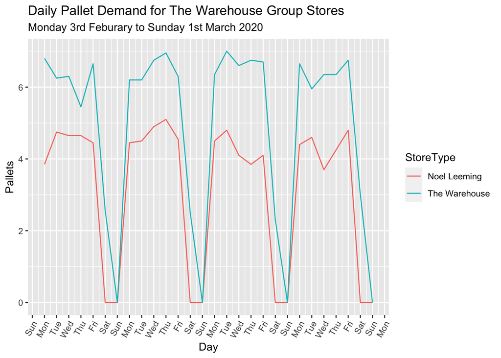

```r
# plotting demand time series
demandData.gather %>% group_by(Date,StoreType)%>% summarise(totDemand = mean(Demand,na.rm=TRUE)) %>% ggplot() + geom_line(aes(x = Date, y = totDemand, color = StoreType)) + scale_x_date(date_breaks = "1 day", date_labels = "%a") + labs(title = "Daily Pallet Demand for The Warehouse Group Stores", subtitle = "Monday 3rd Feburary to Sunday 1st March 2020", y  = "Pallets", x = 'Day') + theme(axis.text.x = element_text(angle = 60, hjust = 1))
```

From the plot above it appears that the average daily pallet demand for The Warehouse stores is higher than the Noel Leeming stores. We can also see during the weekdays daily pallet demand seems to relatively constant for each store type. The average daily pallet demand for The Warehouse stores during the weekdays is around 7 pallets whereas for Noel Leeming stores it is around 5 pallets. The Noel Leeming stores do not appear to have any demand for pallets in the weekend. The Warehouse stores only have pallet demand on Saturday but not Sunday. To investigate the demands on different weekdays we will now create a grouped boxplot.

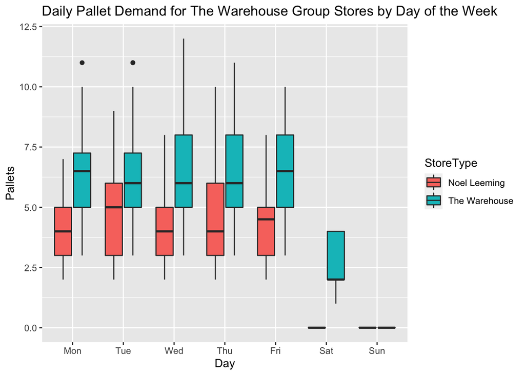

```r
# Distribution of demand for weekdays
demandData.gather %>% group_by(dayOfTheWeek,StoreType) %>% mutate(dayOfTheWeek =  fct_relevel(dayOfTheWeek,"Mon","Tue","Wed","Thu","Fri","Sat","Sun")) %>% ggplot() + geom_boxplot(aes(y=Demand, x = dayOfTheWeek, fill = StoreType))+labs(title = "Daily Pallet Demand for The Warehouse Group Stores by Day of the Week", y  = "Pallets", x = 'Day')
```

From the boxplot above it would appears an appropriate estimate for daily pallet demand can be made by spliting demand into 3 groups. The groups are as follows; The Warehouse stores during the weekdays, Noel Leeming stores during the weekdays, The Warehouse stores on Saturday. With the daily pallet demand for Noel Leeming stores in the weekend being 0 and the daily pallet demand for The Warehouse on Sunday also being 0. To find a suitable estimate of demand for these different groups we will consider the following violin plots.

```r
#mean_demand = demandData.gather %>%  filter(dayOfTheWeek != "Sat") %>% filter(dayOfTheWeek != "Sun") %>% group_by(Name) %>% summarise(meanDemand = mean(Demand,na.rm=TRUE))
#mean_demand = arrange(mean_demand,match(mean_demand$Name,stores$Store))
#stores.filtered$meanDemand = mean_demand$meanDemand
#stores.filtered %>% group_by(Type) %>% ggplot() + geom_violin(aes(x = Type, y = meanDemand, fill = Type))
```

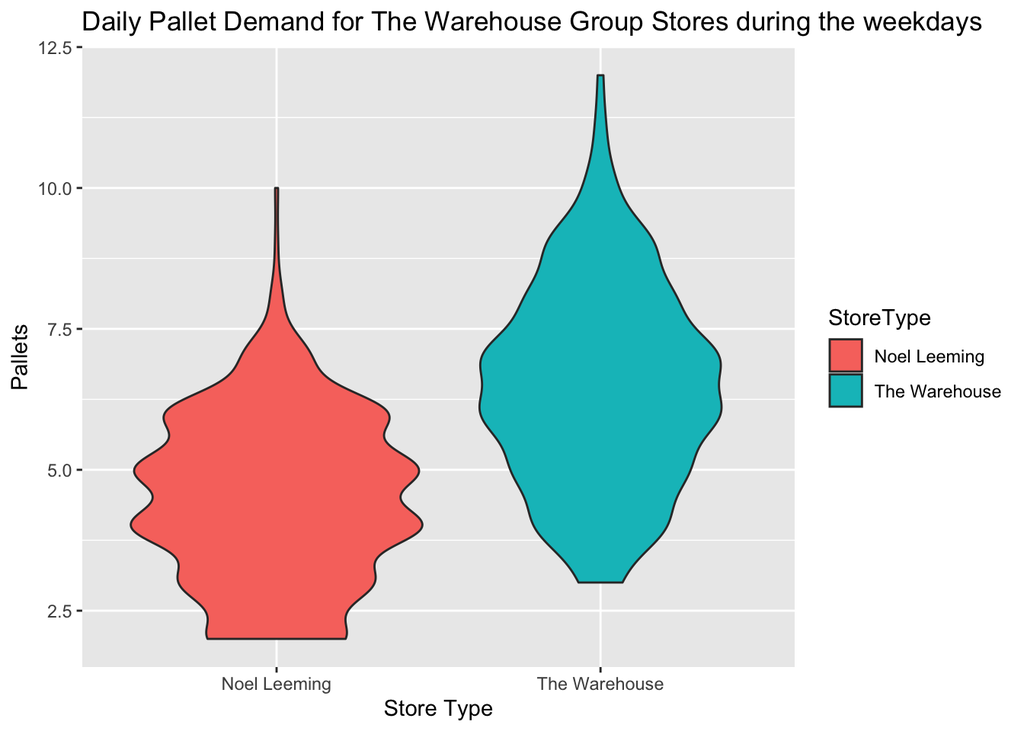

```r
# Weekday demand
#demandData.gather %>% filter(dayOfTheWeek != "Sat") %>% filter(dayOfTheWeek != "Sun") %>% group_by(StoreType) %>% ggplot() + geom_boxplot(aes(y=Demand, fill = StoreType))

demandData.gather %>% filter(dayOfTheWeek != "Sat") %>%  filter(dayOfTheWeek != "Sun") %>% group_by(StoreType) %>% ggplot() + geom_violin(aes(y=Demand,x = StoreType, fill = StoreType))+ labs(title = "Daily Pallet Demand for The Warehouse Group Stores during the weekdays", y  = "Pallets", x = 'Store Type')
```

From the box and violin plot above it appears that a suitable estimate for the daily pallet demand for Noel Leeming stores is 6 pallets per weekday. Similarly a suitable estimate for the daily pallet demand for The Warehouse stores is 8 pallets per day. These estimates around the 75th percentile will ensure that most days the trucks will be able to transport enough pallets to satisfy demand of the stores.

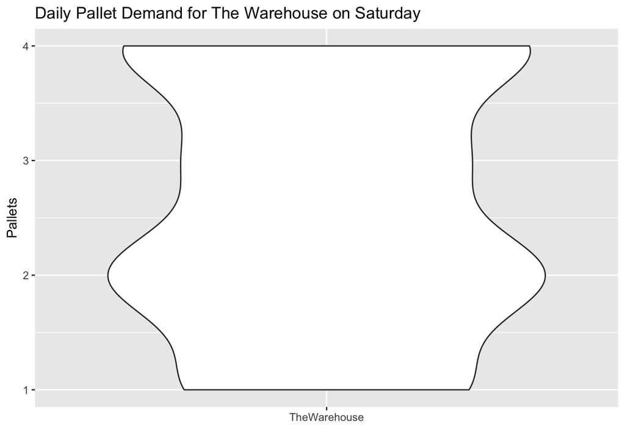

```r
# The Warehouse Saturday demand
#demandData.gather %>% filter(dayOfTheWeek == "Sat" & StoreType == "The Warehouse") %>% group_by(StoreType) %>% ggplot() + geom_boxplot(aes(y=Demand, fill = StoreType))

demandData.gather %>% filter(dayOfTheWeek == "Sat" & StoreType == "The Warehouse") %>% group_by(StoreType) %>% ggplot() + geom_violin(aes(y=Demand,x = "TheWarehouse",))+ labs(title = "Daily Pallet Demand for The Warehouse on Saturday", y  = "Pallets",x = "")
```

From the plots above an appropriate estimate for the daily pallet demand for The Warehouse stores on Saturday is 3 pallets per store. Once again by estimating daily demand to be above the mean demand this should ensure that most of the time the trucks can carry enough pallets to meet store demand.